# re_stepwise

Robbert Kouwenhoven

2025-04-13

```r
library(dplyr)
```

```r
library(ggplot2)
```

```r
half_hourly_fluxes <- readr::read_csv("../raw_data/half_hourly_fluxes.csv")
half_hourly_fluxes
```

```
## # A tibble: 23,011 × 17
##    siteid TIMESTAMP    TA_F SW_IN_F LW_IN_F VPD_F  PA_F   P_F  WS_F TA_F_MDS
##    <chr>  <date>      <dbl>   <dbl>   <dbl> <dbl> <dbl> <dbl> <dbl>    <dbl>
##  1 CH-Dav 1997-01-01 -4.57     77.4    223. 0.565  82.6   0.4 0.559   -4.57
##  2 CH-Dav 1997-01-02 -3.34     45.6    235. 0.978  82.9   0   1.11    -3.34
##  3 CH-Dav 1997-01-03  0.278    74.1    239. 2.24   82.4   0   2.03     0.278
##  4 CH-Dav 1997-01-04 -1.88     58.1    250. 1.38   81.7   1.8 1.92    -1.88
##  5 CH-Dav 1997-01-05 -4.96     80.8    248. 1.16   82.3   0   0.407   -4.96
##  6 CH-Dav 1997-01-06 -4.48     59.6    237. 0.838  82.7   0   0.466   -4.48
##  7 CH-Dav 1997-01-07 -3.15     45.5    234. 1.33   82.9   0   1.03    -3.15
##  8 CH-Dav 1997-01-08 -2.45     76.7    222. 1.87   82.7   0   1.95    -2.45
##  9 CH-Dav 1997-01-09 -2.43     47.6    251. 1.44   82.2   0   0.785   -2.43
## 10 CH-Dav 1997-01-10 -3.09     39.6    242. 0.776  82.8   0   1.25    -3.09
## # ℹ 23,001 more rows
## # ℹ 7 more variables: SW_IN_F_MDS <dbl>, LW_IN_F_MDS <dbl>, VPD_F_MDS <dbl>,
## #   CO2_F_MDS <dbl>, PPFD_IN <dbl>, GPP_NT_VUT_REF <dbl>, USTAR <dbl>
```

```r
tibble::tibble(vars = names(half_hourly_fluxes))
```

```
## # A tibble: 17 × 1
##    vars
##    <chr>
##  1 siteid
##  2 TIMESTAMP
##  3 TA_F
##  4 SW_IN_F
##  5 LW_IN_F
##  6 VPD_F
##  7 PA_F
##  8 P_F
##  9 WS_F
## 10 TA_F_MDS
## 11 SW_IN_F_MDS
## 12 LW_IN_F_MDS
## 13 VPD_F_MDS
## 14 CO2_F_MDS
## 15 PPFD_IN
## 16 GPP_NT_VUT_REF
## 17 USTAR
```

```r
clean_fluxes <- half_hourly_fluxes %>%
  na.omit()
clean_fluxes
```

```
## # A tibble: 9,494 × 17
##    siteid TIMESTAMP    TA_F SW_IN_F LW_IN_F VPD_F  PA_F   P_F  WS_F TA_F_MDS
##    <chr>  <date>      <dbl>   <dbl>   <dbl> <dbl> <dbl> <dbl> <dbl>    <dbl>
##  1 CH-Dav 2006-05-30 -0.776    183.    271. 1.08   82.8   5    3.36   -0.776
##  2 CH-Dav 2006-05-31 -1.08     266.    257. 0.77   83.2   1.6  2.57   -1.08
##  3 CH-Dav 2006-06-01 -0.671    166.    272. 0.938  83.7   1.9  2.24   -0.671
##  4 CH-Dav 2006-06-02 -0.638    192.    265. 1.22   83.9   0.1  2.51   -0.638
##  5 CH-Dav 2006-06-03  1.93     202.    259. 1.68   84.1   0.2  1.75    1.93
##  6 CH-Dav 2006-06-04  2.78     104.    273. 0.761  83.9   6.4  1.46    2.78
##  7 CH-Dav 2006-06-05  3.24     144.    272. 1.38   83.9   1    1.38    3.24
##  8 CH-Dav 2006-06-06  3.7      245.    271. 1.98   84.0   2.7  2.19    3.7
##  9 CH-Dav 2006-06-07  4.72     360.    266. 4.1    84.2   0    1.77    4.72
## 10 CH-Dav 2006-06-08  7.14     320.    277. 4.99   84.2   0    2.06    7.14
## # ℹ 9,484 more rows
## # ℹ 7 more variables: SW_IN_F_MDS <dbl>, LW_IN_F_MDS <dbl>, VPD_F_MDS <dbl>,
## #   CO2_F_MDS <dbl>, PPFD_IN <dbl>, GPP_NT_VUT_REF <dbl>, USTAR <dbl>
```

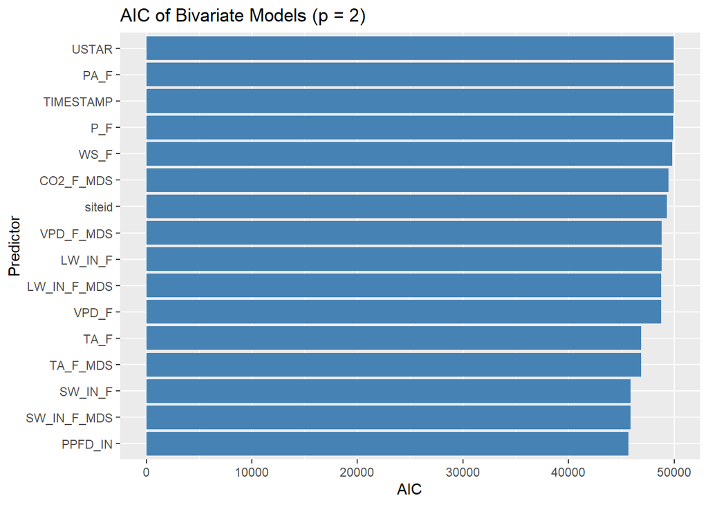

```r
# Get predictor names
predictors <- names(clean_fluxes)[names(clean_fluxes) != "GPP_NT_VUT_REF"]

# Fit bivariate models and store AIC + R²
bivariate_results <- lapply(predictors, function(var) {
  formula <- as.formula(paste("GPP_NT_VUT_REF ~", var))
  model <- lm(formula, data = clean_fluxes)
  data.frame(
    predictor = var,
    AIC = AIC(model),
    R2 = summary(model)$r.squared
  )
})

# Combine results into a data frame
bivariate_models <- do.call(rbind, bivariate_results)

# Plot AIC for each bivariate model
ggplot(bivariate_models, aes(x = reorder(predictor, AIC), y = AIC)) +
  geom_col(fill = "steelblue") +
  coord_flip() +
  labs(x = "Predictor", y = "AIC", title = "AIC of Bivariate Models (p = 2)")
```

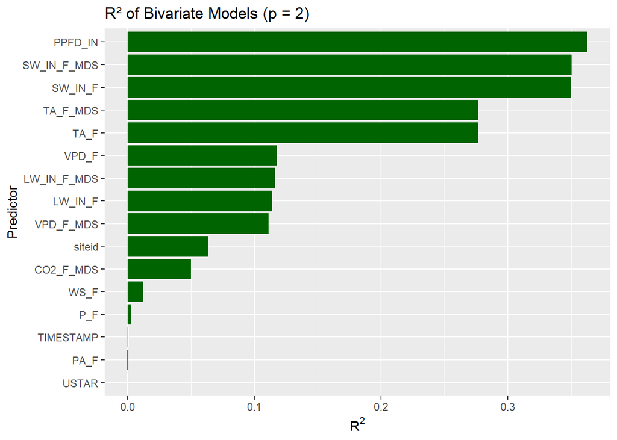

```r
# Plot R² for each bivariate model
ggplot(bivariate_models, aes(x = reorder(predictor, R2), y = R2)) +
  geom_col(fill = "darkgreen") +
  coord_flip() +
  labs(x = "Predictor", y = expression(R^2), title = "R² of Bivariate Models (p = 2)")
```

Part 1 - bivariate models: This script computes a linear regression using two parameters (and hence 1 variable) for all possible combinations ( = number of variables). For every predictor, a linear model is fitted and AIC + R^2 is computed. Both R^2 and AIC are then visualized for every predictor. As can be seen well in the plots, the predictors corresponding to a high AIC have a low R^2 and vice versa - as expected for a single predictor.

```r
# initial conditions: all predictors are remaining, no predictors are selected, and every new model is better than the current (AIC=infinity)
predictors <- names(clean_fluxes)[names(clean_fluxes) != "GPP_NT_VUT_REF"]
remaining <- predictors
selected <- c()
aic_old <- Inf

# Store AIC and R2 at each step
aic_trace <- data.frame(p = integer(), var_added = character(), R2 = numeric(), AIC = numeric(), stringsAsFactors = FALSE)

repeat {
  cat("\n--- Step", length(selected) + 1, "---\n")

  aic_results <- lapply(remaining, function(var) {
    current_vars <- c(selected, var)
    formula <- as.formula(paste("GPP_NT_VUT_REF ~", paste(current_vars, collapse = " + ")))

    result <- tryCatch({
      model <- lm(formula, data = clean_fluxes)
      rsq <- summary(model)$r.squared
      aic_val <- AIC(model)
      data.frame(var = var, R2 = rsq, AIC = aic_val)
    }, error = function(e) {
      NULL
    })

    return(result)
  })

  # Filter out failed models
  aic_results <- Filter(Negate(is.null), aic_results)

  # Check if anything is left
  if (length(aic_results) == 0) {
    warning("No more valid models could be fitted.")
    break
  }

  # Bind results
  aic_df <- do.call(rbind, aic_results)
  print(aic_df)  # Show R2 and AIC for each variable tested

  best <- aic_df[which.min(aic_df$AIC), ]

  cat("Best variable to add:", best$var, "\n")
  cat("R2:", round(best$R2, 4), "\n")
  cat("AIC (new):", round(best$AIC, 2), "\n")
  cat("AIC (old):", round(aic_old, 2), "\n")

  if (!is.na(best$AIC) && best$AIC < aic_old) {
    selected <- c(selected, best$var)
    remaining <- setdiff(remaining, best$var)
    aic_old <- best$AIC
    aic_trace <- rbind(aic_trace, data.frame(p = length(selected), var_added = best$var, R2 = best$R2, AIC = aic_old))
  } else {
    cat("AIC did not improve. Stopping selection.\n")
    break
  }
}
```

```
##
## --- Step 1 ---
##            var           R2      AIC
## 1       siteid 6.385592e-02 49338.96
## 2    TIMESTAMP 5.048372e-04 49956.63
## 3         TA_F 2.766277e-01 46886.97
## 4      SW_IN_F 3.503274e-01 45866.79
## 5      LW_IN_F 1.142586e-01 48809.52
## 6        VPD_F 1.179701e-01 48769.65
## 7         PA_F 2.874295e-04 49958.70
## 8          P_F 2.967794e-03 49933.21
## 9         WS_F 1.229558e-02 49843.97
## 10    TA_F_MDS 2.766429e-01 46886.78
## 11 SW_IN_F_MDS 3.504158e-01 45865.50
## 12 LW_IN_F_MDS 1.163707e-01 48786.85
## 13   VPD_F_MDS 1.115091e-01 48838.94
## 14   CO2_F_MDS 5.012735e-02 49473.18
## 15     PPFD_IN 3.627837e-01 45682.99
## 16       USTAR 3.090633e-05 49961.14
## Best variable to add: PPFD_IN
## R2: 0.3628
## AIC (new): 45682.99
## AIC (old): Inf
##
## --- Step 2 ---
##            var        R2      AIC
## 1       siteid 0.4678716 43977.94
## 2    TIMESTAMP 0.3627838 45684.99
## 3         TA_F 0.3956078 45182.90
## 4      SW_IN_F 0.3628074 45684.64
## 5      LW_IN_F 0.4374452 44501.85
## 6        VPD_F 0.3899363 45271.57
## 7         PA_F 0.3636282 45672.40
## 8          P_F 0.3707088 45566.18
## 9         WS_F 0.3658335 45639.45
## 10    TA_F_MDS 0.3956119 45182.83
## 11 SW_IN_F_MDS 0.3628051 45684.68
## 12 LW_IN_F_MDS 0.4364004 44519.46
## 13   VPD_F_MDS 0.3907807 45258.42
## 14   CO2_F_MDS 0.3631593 45679.40
```

[output cut: 177 more lines]

```
## Best variable to add: P_F
## R2: 0.6143
## AIC (new): 40945.52
## AIC (old): 40950.83
##
## --- Step 14 ---
##           var        R2      AIC
## 1        TA_F 0.6143059 40946.39
## 2 SW_IN_F_MDS 0.6142649 40947.40
## 3 LW_IN_F_MDS 0.6142811 40947.00
## Best variable to add: TA_F
## R2: 0.6143
## AIC (new): 40946.39
## AIC (old): 40945.52
## AIC did not improve. Stopping selection.
```

```r
cat("\nFinal variable selection order:\n")
```

```
##
## Final variable selection order:
```

```r
print(selected)
```

```
##  [1] "PPFD_IN"   "siteid"    "LW_IN_F"   "VPD_F_MDS" "TA_F_MDS"  "SW_IN_F"
##  [7] "WS_F"      "USTAR"     "VPD_F"     "CO2_F_MDS" "PA_F"      "TIMESTAMP"
## [13] "P_F"
```

```r
cat("\nAIC trace:\n")
```

```
##
## AIC trace:
```

```r
print(aic_trace)
```

```
##     p var_added        R2      AIC
## 1   1   PPFD_IN 0.3627837 45682.99
## 2   2    siteid 0.4678716 43977.94
## 3   3   LW_IN_F 0.5466794 42458.20
## 4   4 VPD_F_MDS 0.5647949 42073.01
## 5   5  TA_F_MDS 0.5890255 41531.13
## 6   6   SW_IN_F 0.5979195 41325.42
## 7   7      WS_F 0.6047728 41164.20
## 8   8     USTAR 0.6106971 41022.81
## 9   9     VPD_F 0.6119628 40993.89
## 10 10 CO2_F_MDS 0.6129432 40971.88
## 11 11      PA_F 0.6135409 40959.21
## 12 12 TIMESTAMP 0.6139628 40950.83
## 13 13       P_F 0.6142601 40945.52
```

Here’s how it works:

- Initialization: The set of all candidate predictors is stored in remaining. The vector selected starts empty, and aic_old is initialized with infinity to represent the worst possible AIC.
- Iterations inside the repeat loop: At each step, the script evaluates all possible models that add one new predictor from remaining to the current set of selected predictors. For each candidate variable it builds a new formula by combining the selected variables with the current candidate. Then it fits a linear regression model using this formula. The AIC of the model is computed and stored the variable name and AIC in a data frame. Models that fail to fit (due to errors) are skipped using tryCatch().
- Model selection: The script identifies the model with the lowest AIC among the candidates. If this new model improves over the previous best AIC (aic_old), it adds the selected variable to the selected list, removes it from remaining, updates aic_old with the new best AIC, and logs the current number of parameters and its AIC in aic_trace.
- Stopping criterion: If no improvement in AIC is found (i.e. adding more predictors makes the model worse), the loop stops.

The model with the lowest AIC and its corresponding variables is considered the final (presumably optimal) model.

Printed is for every loop with parameters p what the R^2 and AIC would be with the addition of this new variable from ‘remaining’.

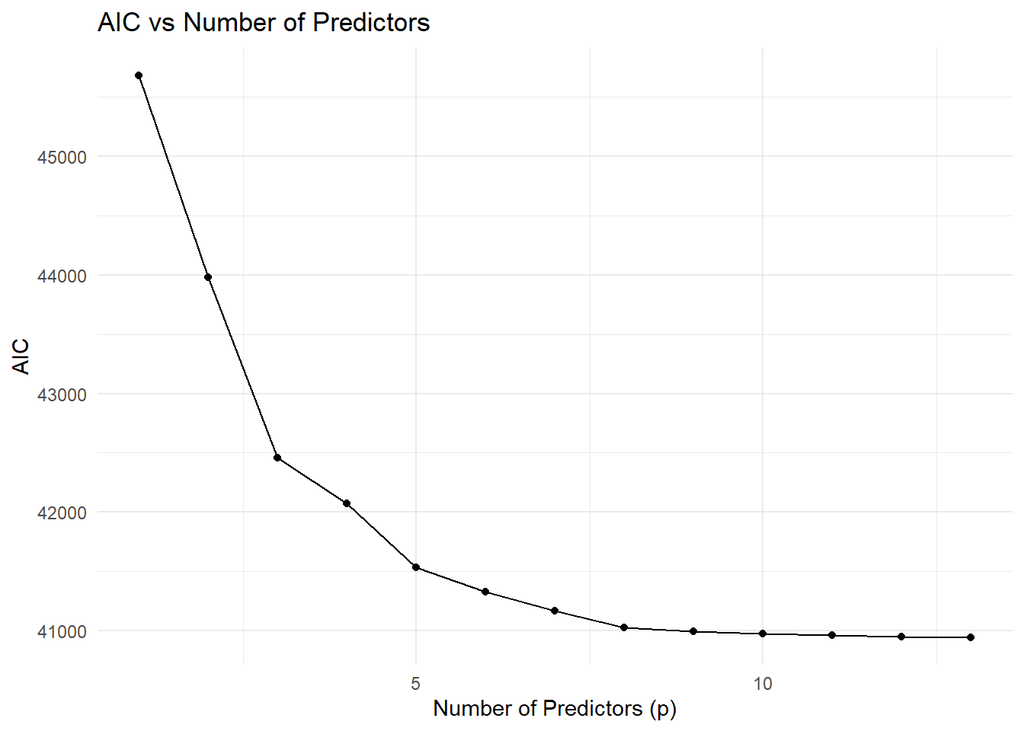

```r
# Plot
ggplot(aic_trace, aes(x = p, y = AIC)) +
  geom_line() +
  geom_point() +
  labs(title = "AIC vs Number of Predictors",
       x = "Number of Predictors (p)",
       y = "AIC") +
  theme_minimal()
```

```r
# Final model
final_formula <- as.formula(paste("GPP_NT_VUT_REF ~", paste(selected, collapse = " + ")))
final_model <- lm(final_formula, data = clean_fluxes)
summary(final_model)
```

```
##
## Call:
## lm(formula = final_formula, data = clean_fluxes)
##
## Residuals:
##     Min      1Q  Median      3Q     Max
## -8.3266 -1.3772 -0.0225  1.3198 11.2120
##
## Coefficients:
##                Estimate Std. Error t value Pr(>|t|)
## (Intercept)  -8.268e+00  2.761e+00  -2.995 0.002756 **
## PPFD_IN       2.350e-03  5.965e-04   3.939 8.23e-05 ***
## siteidCH-Lae  3.120e-01  3.137e-01   0.994 0.320043
## siteidFI-Hyy  2.310e-03  5.026e-01   0.005 0.996333
## siteidFR-Pue -2.746e+00  4.685e-01  -5.860 4.78e-09 ***
## LW_IN_F       9.811e-03  9.430e-04  10.404  < 2e-16 ***
## VPD_F_MDS    -1.507e-01  3.277e-02  -4.600 4.28e-06 ***
## TA_F_MDS      1.643e-01  7.756e-03  21.188  < 2e-16 ***
## SW_IN_F       1.760e-02  1.280e-03  13.751  < 2e-16 ***
## WS_F         -7.687e-01  4.754e-02 -16.170  < 2e-16 ***
## USTAR         3.227e+00  2.638e-01  12.230  < 2e-16 ***
## VPD_F        -1.863e-01  3.417e-02  -5.453 5.07e-08 ***
## CO2_F_MDS    -3.158e-03  9.944e-04  -3.176 0.001499 **
## PA_F          1.033e-01  3.117e-02   3.315 0.000921 ***
## TIMESTAMP    -8.160e-05  2.468e-05  -3.306 0.000949 ***
## P_F          -1.050e-02  3.886e-03  -2.703 0.006887 **
## ---
## Signif. codes:  0 '***' 0.001 '**' 0.01 '*' 0.05 '.' 0.1 ' ' 1
##
## Residual standard error: 2.089 on 9478 degrees of freedom
## Multiple R-squared:  0.6143, Adjusted R-squared:  0.6136
## F-statistic:  1006 on 15 and 9478 DF,  p-value: < 2.2e-16
```

In the end, only 3 variables out of half_hourly_fluxes are not used. Apparently even using variables like side_ID is able to improve the model. This indicates that there are differences in behaviour of GPP depending on the site, which is not represented in other variables in half_hourly_fluxes. The only variables that won’t improve the models performance are the air temperature TA_F and the gapfilled versions of both incoming longwave and shortwave radiation. Note that the not-gapfilled variables LW_IN_F and SW_IN_F are included.